# 1822 Performance Task

Jie Heng Yu

11/5/2023

# 1822 Performance Task

# Data Preparation

To begin, we read in the original datasets.

```r
testScoreDF <- as_tibble(read.csv('test_scores.csv'))
testScoreDF
```

```
## # A tibble: 21,059 × 18
##    Schno School   Calgrade Englang Econ_Dis Sped  HL    NA.   Asian Hawaiian
##    <int> <chr>       <int> <chr>   <chr>    <chr> <chr> <chr> <chr> <chr>
##  1   413 Alamo ES        3 EO      Yes      No    No    No    Yes   No
##  2   413 Alamo ES        3 EO      No       No    No    No    No    No
##  3   413 Alamo ES        3 EO      No       No    No    No    Yes   No
##  4   413 Alamo ES        3 EL      Yes      No    Yes   No    No    No
##  5   413 Alamo ES        3 EO      No       No    No    No    No    No
##  6   413 Alamo ES        3 EL      Yes      No    No    No    Yes   No
##  7   413 Alamo ES        3 EL      No       No    No    No    Yes   No
##  8   413 Alamo ES        3 EO      Yes      Yes   No    No    Yes   No
##  9   413 Alamo ES        3 EL      Yes      No    Yes   No    No    No
## 10   413 Alamo ES        3 IFEP    No       No    No    No    Yes   No
## # ℹ 21,049 more rows
## # ℹ 8 more variables: Filipino <chr>, AA <chr>, White <chr>, Multi_Race <chr>,
## #   ELASS <int>, ELA_AL <int>, MathSS <int>, Math_AL <int>
```

```r
surveyDF <- as_tibble(read.csv('survey_responses.csv'))
surveyDF
```

```
## # A tibble: 4,984 × 8
##    schno school   span       group           domain construct favorability count
##    <int> <chr>    <chr>      <chr>           <chr>  <chr>            <int> <int>
##  1     0 District Elementary African Americ… Cultu… Climate …           78    NA
##  2     0 District Elementary African Americ… Cultu… Knowledg…           66    NA
##  3     0 District Elementary African Americ… Cultu… Safety              55    NA
##  4     0 District Elementary African Americ… Cultu… Sense of…           65    NA
##  5     0 District Elementary African Americ… Socia… Growth M…           59    NA
##  6     0 District Elementary African Americ… Socia… Self-Eff…           60    NA
##  7     0 District Elementary African Americ… Socia… Self-Man…           57    NA
##  8     0 District Elementary African Americ… Socia… Social A…           62    NA
##  9     0 District Elementary All             Cultu… Climate …           80    NA
## 10     0 District Elementary All             Cultu… Knowledg…           75    NA
## # ℹ 4,974 more rows
```

Since we want to work with data for K-8 schools, we’ll reduce the datasets to only have K-8 schools.

```r
testScoreDF <- filter(testScoreDF, grepl('K-8', School))
testScoreDF
```

```
## # A tibble: 2,302 × 18
##    Schno School       Calgrade Englang Econ_Dis Sped  HL    NA.   Asian Hawaiian
##    <int> <chr>           <int> <chr>   <chr>    <chr> <chr> <chr> <chr> <chr>
##  1   618 Buena Vista…        3 EL      Yes      No    Yes   No    No    No
##  2   618 Buena Vista…        3 EO      Yes      No    Yes   No    No    No
##  3   618 Buena Vista…        3 EL      Yes      Yes   Yes   No    No    No
##  4   618 Buena Vista…        3 EO      No       Yes   Yes   No    No    No
##  5   618 Buena Vista…        3 EO      No       No    No    No    No    No
##  6   618 Buena Vista…        3 EL      Yes      No    Yes   No    No    No
##  7   618 Buena Vista…        3 EL      Yes      No    Yes   No    No    No
##  8   618 Buena Vista…        3 EL      Yes      No    Yes   No    No    No
##  9   618 Buena Vista…        3 EO      Yes      Yes   No    No    No    No
## 10   618 Buena Vista…        3 EL      Yes      No    Yes   No    No    No
## # ℹ 2,292 more rows
## # ℹ 8 more variables: Filipino <chr>, AA <chr>, White <chr>, Multi_Race <chr>,
## #   ELASS <int>, ELA_AL <int>, MathSS <int>, Math_AL <int>
```

```r
surveyDF <- filter(surveyDF, grepl('K8', school))
surveyDF
```

```
## # A tibble: 352 × 8
##    schno school            span       group  domain construct favorability count
##    <int> <chr>             <chr>      <chr>  <chr>  <chr>            <int> <int>
##  1   479 Lilienthal Alt K8 Elementary Asian  Cultu… Climate …           84    41
##  2   479 Lilienthal Alt K8 Elementary Asian  Cultu… Knowledg…           84    41
##  3   479 Lilienthal Alt K8 Elementary Asian  Cultu… Safety              72    41
##  4   479 Lilienthal Alt K8 Elementary Asian  Cultu… Sense of…           83    41
##  5   479 Lilienthal Alt K8 Elementary Asian  Socia… Growth M…           64    41
##  6   479 Lilienthal Alt K8 Elementary Asian  Socia… Self-Eff…           58    41
##  7   479 Lilienthal Alt K8 Elementary Asian  Socia… Self-Man…           80    41
##  8   479 Lilienthal Alt K8 Elementary Asian  Socia… Social A…           68    41
##  9   479 Lilienthal Alt K8 Elementary Hispa… Cultu… Climate …           79    22
## 10   479 Lilienthal Alt K8 Elementary Hispa… Cultu… Knowledg…           81    22
## # ℹ 342 more rows
```

Let’s see which schools we are working with.

```r
unique(testScoreDF$School)
```

```
## [1] "Buena Vista Horace Mann K-8" "Carmichael (Bessie) K-8"
## [3] "Lawton K-8"                  "Lilienthal (Claire) K-8"
## [5] "Revere (Paul) K-8"           "Rooftop K-8"
## [7] "SF Community K-8"            "Yu (Alice Fong) K-8"
```

```r
unique(surveyDF$school)
```

```
## [1] "Lilienthal Alt K8"    "Yu (A.F.) Alt K8"     "Buena Vista/ Mann K8"
## [4] "Lawton Alt K8"        "Rooftop Alt K8"
```

Looks like there are only five K-8 schools that have completed the survey. We have the test scores of eight K-8 schools. For the three K-8 schools that did not complete the survey, we won’t be able to see the their students’ performance patterns vary across their growth mindsets or the school’s culture/climate.

We’ll clean up both datasets so they use similar terminology, remove unnecessary columns, separate out the three K-8 schools who didn’t complete surveys into another dataset so I don’t get confused. Hawaiian students are lumped in with Asian students, so we’ll recode the ‘Asian’ column to reflect that. We are only interested in the English learners in the `Englang` column, so we will recode everything that isn’t ‘EL’ to ‘Else’. Since being an English language learner, being part of the special education program, & having low socio-economic status are not mutually exclusive with each other or any ethnic subgroup specified for the analysis of this data, we will perform analysis on the program groups & ethnic groups separately. That being said, I will create two new columns for program groups & ethnic groups for future ease of analysis.

```r
testScoreDF$School <- recode(testScoreDF$School, 'Buena Vista Horace Mann K-8' = 'Buena Vista/ Mann K8', 'Lawton K-8' = 'Lawton Alt K8', 'Lilienthal (Claire) K-8' = 'Lilienthal Alt K8', 'Rooftop K-8' = 'Rooftop Alt K8', 'Yu (Alice Fong) K-8' = 'Yu (A.F.) Alt K8')
testScoreDF$Asian[testScoreDF$Hawaiian == 'Yes'] <- 'Yes'
testScoreDF$Calgrade <- case_when(testScoreDF$Calgrade %in% 1:5 ~ 'Elementary',
                                  TRUE ~ 'Middle')
testScoreDF$Englang[testScoreDF$Englang != 'EL'] <- 'Else'
testScoreDF <- select(testScoreDF, -Hawaiian, -Filipino, -Multi_Race, -NA.)
surveyDF <- select(surveyDF, -count)
testScoreDF$ProgramGroup <- apply(testScoreDF, 1, function(x) {
  if (x['Englang'] == 'EL' & x['Econ_Dis'] == 'Yes' & x['Sped'] == 'Yes') {
    testScoreDF$ProgramGroup <- 'EL & SES & SPED'
  } else if (x['Englang'] == 'EL' & x['Econ_Dis'] == 'Yes' & x['Sped'] == 'No') {
    testScoreDF$ProgramGroup <- 'EL & SES'
  } else if (x['Englang'] == 'EL' & x['Econ_Dis'] == 'No' & x['Sped'] == 'Yes') {
    testScoreDF$ProgramGroup <- 'EL & SPED'
  } else if (x['Englang'] == 'Else' & x['Econ_Dis'] == 'Yes' & x['Sped'] == 'Yes') {
    testScoreDF$ProgramGroup <- 'SES & SPED'
  } else if (x['Englang'] == 'EL' & x['Econ_Dis'] == 'No' & x['Sped'] == 'No') {
    testScoreDF$ProgramGroup <- 'EL'
  } else if (x['Englang'] == 'Else' & x['Econ_Dis'] == 'Yes' & x['Sped'] == 'No') {
    testScoreDF$ProgramGroup  <- 'SES'
  } else {
    testScoreDF$ProgramGroup <- 'SPED'
  }
})
testScoreDF$EthnicGroup <- apply(testScoreDF, 1, function(x) {
  if (x['HL'] == 'Yes') {testScoreDF$EthnicGroup <- 'HL'}
  else if (x['Asian'] == 'Yes') {testScoreDF$EthnicGroup <- 'Asian'}
  else if (x['AA'] == 'Yes') {testScoreDF$EthnicGroup <- 'AA'}
  else {testScoreDF$EthnicGroup <- 'White'}
})
testScoreDF <- select(testScoreDF, School, ProgramGroup, EthnicGroup, ELASS, MathSS)
surveyDF <- filter(surveyDF, group %in% c('African American', 'Hispanic/Latino', 'Asian', 'White', 'Low SES', 'SPED', 'ELL'))
unique(surveyDF$group)
```

```
## [1] "Asian"           "Hispanic/Latino" "Low SES"         "SPED"
## [5] "White"           "ELL"
```

It’s looks like African American students did not complete the survey at any K-8 school, so we will take them out when accounting for student performance across school culture/climate or growth mindset.

```r
testScoreDF
```

```
## # A tibble: 2,302 × 5
##    School               ProgramGroup    EthnicGroup ELASS MathSS
##    <chr>                <chr>           <chr>       <int>  <int>
##  1 Buena Vista/ Mann K8 EL & SES        HL           2249   2212
##  2 Buena Vista/ Mann K8 SES             HL           2373   2432
##  3 Buena Vista/ Mann K8 EL & SES & SPED HL           2255   2301
##  4 Buena Vista/ Mann K8 SPED            HL           2275   2370
##  5 Buena Vista/ Mann K8 SPED            White        2401   2420
##  6 Buena Vista/ Mann K8 EL & SES        HL           2393   2419
##  7 Buena Vista/ Mann K8 EL & SES        HL           2425   2390
##  8 Buena Vista/ Mann K8 EL & SES        HL           2341   2363
##  9 Buena Vista/ Mann K8 SES & SPED      White        2404   2455
## 10 Buena Vista/ Mann K8 EL & SES        HL           2227   2265
## # ℹ 2,292 more rows
```

```r
surveyDF
```

```
## # A tibble: 272 × 7
##    schno school            span       group        domain construct favorability
##    <int> <chr>             <chr>      <chr>        <chr>  <chr>            <int>
##  1   479 Lilienthal Alt K8 Elementary Asian        Cultu… Climate …           84
##  2   479 Lilienthal Alt K8 Elementary Asian        Cultu… Knowledg…           84
##  3   479 Lilienthal Alt K8 Elementary Asian        Cultu… Safety              72
##  4   479 Lilienthal Alt K8 Elementary Asian        Cultu… Sense of…           83
##  5   479 Lilienthal Alt K8 Elementary Asian        Socia… Growth M…           64
##  6   479 Lilienthal Alt K8 Elementary Asian        Socia… Self-Eff…           58
##  7   479 Lilienthal Alt K8 Elementary Asian        Socia… Self-Man…           80
##  8   479 Lilienthal Alt K8 Elementary Asian        Socia… Social A…           68
##  9   479 Lilienthal Alt K8 Elementary Hispanic/La… Cultu… Climate …           79
## 10   479 Lilienthal Alt K8 Elementary Hispanic/La… Cultu… Knowledg…           81
## # ℹ 262 more rows
```

That looks pretty good for now, if we need to make small changes, we’ll do them later.

# General Analysis

First, we’ll look at average ELASS & MathSS scores for each K-8 school.

```r
testScoreDF %>%
  pivot_longer(cols = c('ELASS', 'MathSS'), names_to = 'Measurement',
               values_to = 'Score') %>%
  group_by(School, Measurement) %>%
  summarise(Avg_Score = mean(Score))
```

```
## # A tibble: 16 × 3
## # Groups:   School [8]
##    School                  Measurement Avg_Score
##    <chr>                   <chr>           <dbl>
##  1 Buena Vista/ Mann K8    ELASS           2445.
##  2 Buena Vista/ Mann K8    MathSS          2460.
##  3 Carmichael (Bessie) K-8 ELASS           2467.
##  4 Carmichael (Bessie) K-8 MathSS          2464.
##  5 Lawton Alt K8           ELASS           2585.
##  6 Lawton Alt K8           MathSS          2601.
##  7 Lilienthal Alt K8       ELASS           2572.
##  8 Lilienthal Alt K8       MathSS          2574.
##  9 Revere (Paul) K-8       ELASS           2418.
## 10 Revere (Paul) K-8       MathSS          2402.
## 11 Rooftop Alt K8          ELASS           2522.
## 12 Rooftop Alt K8          MathSS          2527.
## 13 SF Community K-8        ELASS           2405.
## 14 SF Community K-8        MathSS          2401.
## 15 Yu (A.F.) Alt K8        ELASS           2581.
## 16 Yu (A.F.) Alt K8        MathSS          2592.
```

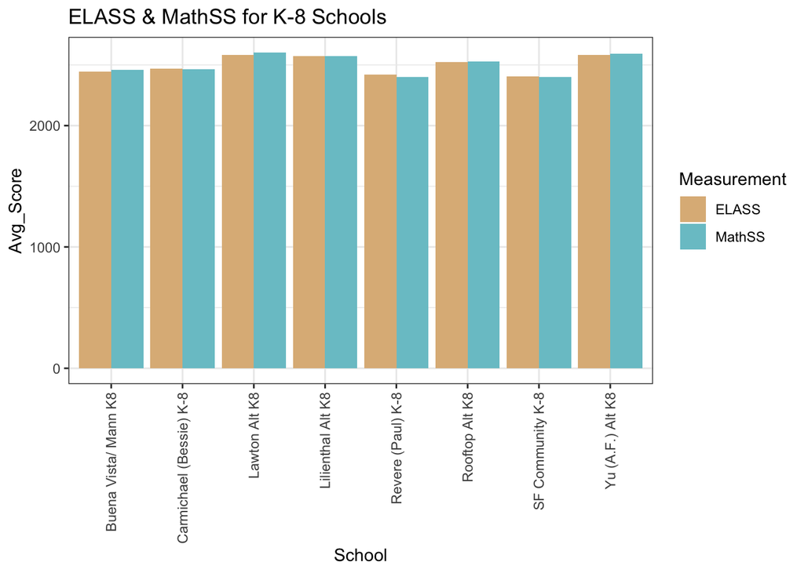

```r
ggplot(testScoreDF %>%
  pivot_longer(cols = c('ELASS', 'MathSS'), names_to = 'Measurement',
               values_to = 'Score') %>%
  group_by(School, Measurement) %>%
  summarise(Avg_Score = mean(Score)),
  aes(x = School, y = Avg_Score, fill = Measurement)) +
  geom_bar(position = 'dodge', stat = 'identity') +
  theme_bw() +
  theme(axis.text.x = element_text(angle = 90, vjust = 0.5, hjust = 1)) +
  labs(title = 'ELASS & MathSS for K-8 Schools') +
  scale_fill_manual(values = c('burlywood', 'cadetblue3'))
```

On average, Lilienthal, Lawton, & Yu A.F. students perform very well on their English & Math assessments. On average, Revere & SF Community students seem to perform worse on their English & Math assessments compared students from other K-8 Schools. Lawton students actually clock in with the highest average ELASS & MathSS scores across all K-8 schools at 2,585 & 2,601, respectively. SF Community students average the lowest ELASS & MathSS scores of all K-8 schools at 2,405 & 2,401.

Now let’s see student performance across program groups.

```r
testScoreDF %>%
  pivot_longer(cols = c('ELASS', 'MathSS'), names_to = 'Measurement',
               values_to = 'Score') %>%
  group_by(School, ProgramGroup, Measurement) %>%
  summarise(Avg_Score = mean(Score))
```

```
## # A tibble: 104 × 4
## # Groups:   School, ProgramGroup [52]
##    School               ProgramGroup    Measurement Avg_Score
##    <chr>                <chr>           <chr>           <dbl>
##  1 Buena Vista/ Mann K8 EL              ELASS           2388.
##  2 Buena Vista/ Mann K8 EL              MathSS          2413.
##  3 Buena Vista/ Mann K8 EL & SES        ELASS           2388.
##  4 Buena Vista/ Mann K8 EL & SES        MathSS          2413.
##  5 Buena Vista/ Mann K8 EL & SES & SPED ELASS           2371.
##  6 Buena Vista/ Mann K8 EL & SES & SPED MathSS          2390.
##  7 Buena Vista/ Mann K8 EL & SPED       ELASS           2364.
##  8 Buena Vista/ Mann K8 EL & SPED       MathSS          2357.
##  9 Buena Vista/ Mann K8 SES             ELASS           2494.
## 10 Buena Vista/ Mann K8 SES             MathSS          2505.
## # ℹ 94 more rows
```

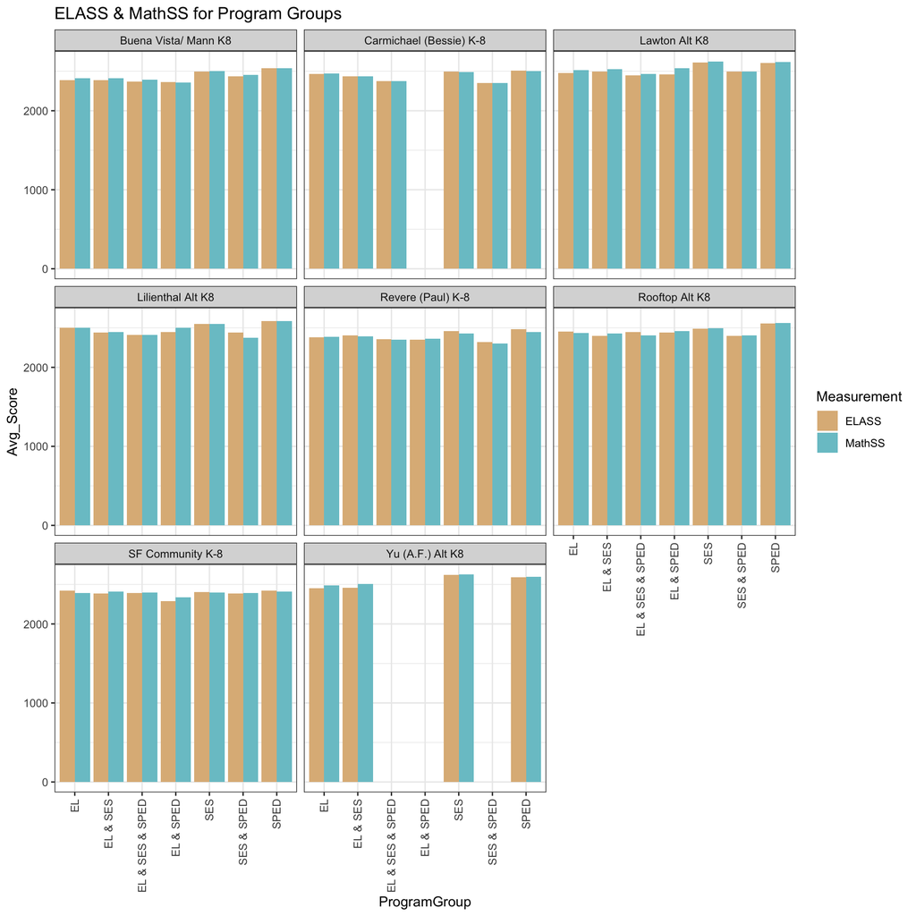

```r
ggplot(testScoreDF %>%
  pivot_longer(cols = c('ELASS', 'MathSS'), names_to = 'Measurement',
               values_to = 'Score') %>%
  group_by(School, ProgramGroup, Measurement) %>%
  summarise(Avg_Score = mean(Score)),
  aes(x = ProgramGroup, y = Avg_Score, fill = Measurement)) +
  geom_bar(position = 'dodge', stat = 'identity') +
  facet_wrap(~ School) +
  theme_bw() +
  theme(axis.text.x = element_text(angle = 90, vjust = 0.5, hjust = 1)) +
  labs(title = 'ELASS & MathSS for Program Groups') +
  scale_fill_manual(values = c('burlywood', 'cadetblue3'))
```

First off, I would like to point out how it’s interesting how Carmichael does not have any EL & SPED students who completed the assessments. But what’s even more interesting is that Yu A.F. does not have EL & SES & SPED students, EL & SPED, & SES & SPED students who completed the assessments. Yu A.F. doesn’t seem to be as diverse as the other K-8 schools in terms of their program groups: I wonder if this is because these are the population values, or there is a selection process to get into Yu A.F. Across all K-8 schools, being EL does seem to have a relationship with lower average ELASS compared to the other program groups. Pure SPED students seem to perform pretty well on both the English & Math assessments compared to other program groups for all K-8 schools. Students who purely have low SES also seem to perform pretty well on both English & Math assessments compared to other program groups for all K-8 schools, implying that having low SES has little or no affect on student performance. Students who are EL & SPED & attend Buena Vista or SF Community don’t perform as well on their assessments compared to other program groups at the same school. Lawton, Lilienthal, & Yu A.F. students seem to perform decently well on their assessments regardless of their program group compared to students in the same program groups at different K-8 schools. This agrees with our figure from earlier. Revere Paul & SF Community students seem to perform worse on their assessments regardless of their program group compared to students in the same program group at different K-8 schools. This also agrees with our earlier figure.

Now, let’s move on to ethnic groups.

```r
testScoreDF %>%
  pivot_longer(cols = c('ELASS', 'MathSS'), names_to = 'Measurement',
               values_to = 'Score') %>%
  group_by(School, EthnicGroup, Measurement) %>%
  summarise(Avg_Score = mean(Score))
```

```
## # A tibble: 46 × 4
## # Groups:   School, EthnicGroup [23]
##    School                  EthnicGroup Measurement Avg_Score
##    <chr>                   <chr>       <chr>           <dbl>
##  1 Buena Vista/ Mann K8    HL          ELASS           2431.
##  2 Buena Vista/ Mann K8    HL          MathSS          2448.
##  3 Buena Vista/ Mann K8    White       ELASS           2563.
##  4 Buena Vista/ Mann K8    White       MathSS          2560.
##  5 Carmichael (Bessie) K-8 AA          ELASS           2383.
##  6 Carmichael (Bessie) K-8 AA          MathSS          2395.
##  7 Carmichael (Bessie) K-8 Asian       ELASS           2514.
##  8 Carmichael (Bessie) K-8 Asian       MathSS          2519.
##  9 Carmichael (Bessie) K-8 HL          ELASS           2434.
## 10 Carmichael (Bessie) K-8 HL          MathSS          2424.
## # ℹ 36 more rows
```

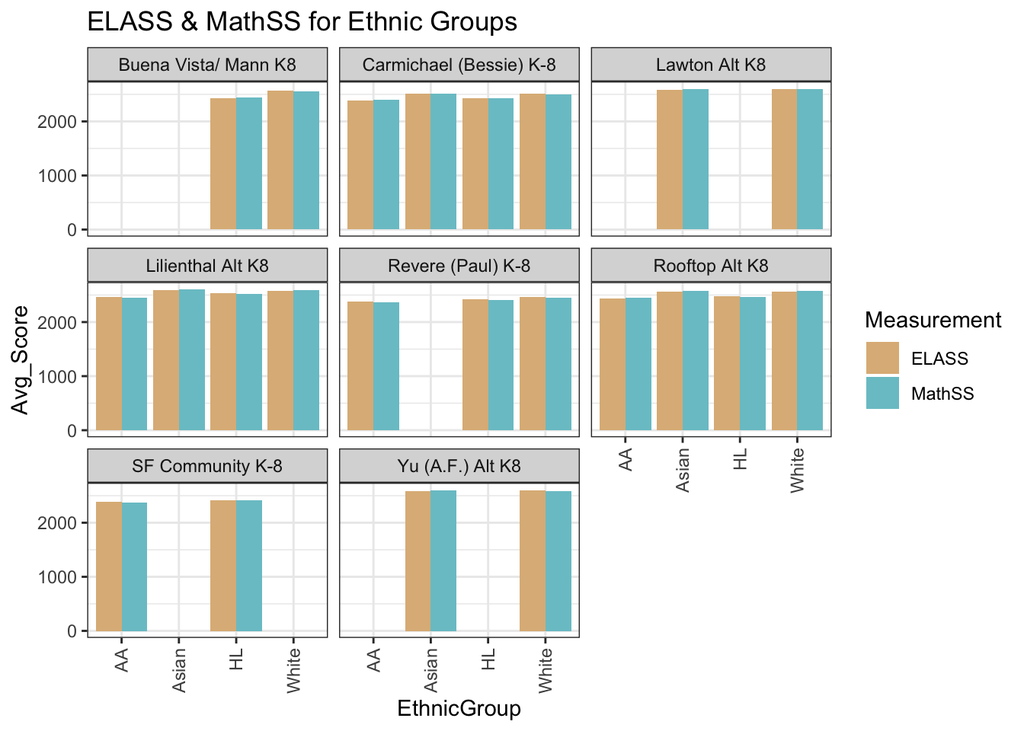

```r
ggplot(testScoreDF %>%
  pivot_longer(cols = c('ELASS', 'MathSS'), names_to = 'Measurement',
               values_to = 'Score') %>%
  group_by(School, EthnicGroup, Measurement) %>%
  summarise(Avg_Score = mean(Score)),
  aes(x = EthnicGroup, y = Avg_Score, fill = Measurement)) +
  geom_bar(position = 'dodge', stat = 'identity') +
  facet_wrap(~ School) +
  theme_bw() +
  theme(axis.text.x = element_text(angle = 90, vjust = 0.5, hjust = 1)) +
  labs(title = 'ELASS & MathSS for Ethnic Groups') +
  scale_fill_manual(values = c('burlywood', 'cadetblue3'))
```

Now this is a lot more interesting. Buena Vista, Yu A.F., & Lawton did not have any AA students who completed the assessments. Buena Vista, Revere, & SF Community did not have Asian students who complete the assessments. Lawton, & Yu A.F did not have HL students who completed the assessments. SF Community did not have White students who completed the assessments. I wonder if this is because the students belong to these ethnic groups just do not attend the school, resulting in no test scores, or there’s a selection process for these schools, or maybe even something else. Asian or White students seem to perform better on their assessments compared to AA or HL students in the same schools, if they completed the assessments. I wonder if higher average assessment scores for each school is related to the number of Asian or White students who completed the assessment for that school.

```r
testScoreDF %>%
  group_by(School, EthnicGroup) %>%
  summarise(Count = n())
```

```
## # A tibble: 23 × 3
## # Groups:   School [8]
##    School                  EthnicGroup Count
##    <chr>                   <chr>       <int>
##  1 Buena Vista/ Mann K8    HL            298
##  2 Buena Vista/ Mann K8    White          36
##  3 Carmichael (Bessie) K-8 AA             45
##  4 Carmichael (Bessie) K-8 Asian          29
##  5 Carmichael (Bessie) K-8 HL             98
##  6 Carmichael (Bessie) K-8 White         130
##  7 Lawton Alt K8           Asian         294
##  8 Lawton Alt K8           White          20
##  9 Lilienthal Alt K8       AA             32
## 10 Lilienthal Alt K8       Asian         137
## # ℹ 13 more rows
```

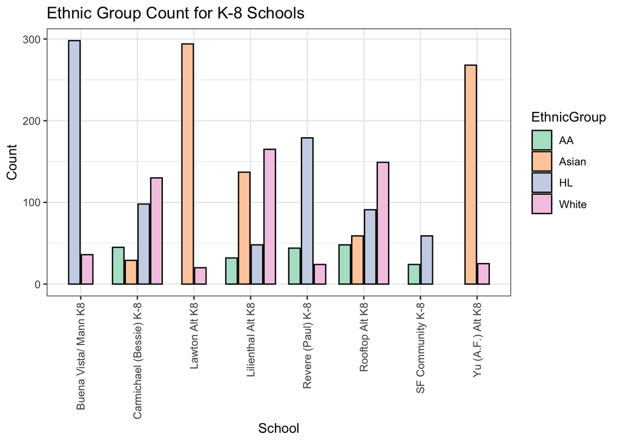

```r
ggplot(testScoreDF %>%
  group_by(School, EthnicGroup) %>%
  summarise(Count = n()),
  aes(x = School, y = Count, fill = EthnicGroup)) +
  geom_bar(colour = 'black', position = position_dodge2(width = 0.5, preserve = 'single'), stat = 'identity') +
  theme_bw() +
  theme(axis.text.x = element_text(angle = 90, vjust = 0.5, hjust = 1)) +
  labs(title = 'Ethnic Group Count for K-8 Schools') +
  scale_fill_brewer(palette = 'Pastel2')
```

As we noticed from before, on average, students from Lilienthal, Lawton, & Yu A.F. seemed to perform better on their assessments than students at other K-8 schools. Well, it seems that there may be a positive relationship between the number of Asian or White students completing the assessments at those schools with & that school’s higher overall assessment scores. Lilienthal, Lawton, & Yu A.F. have a higher number of Asian or White students who completed the assessment compared to other K-8 schools. Notice in Lawton & Yu A.F. that only Asian & White students completed the assessment, but predominantly Asian students account for the variability in the higher average assessment scores for those schools. Lilienthal seems to have a more uniform distribution of Asian & White students – both ethnic groups contributing to the variability in the higher assessment scores for Lilienthal, compared to other K-8 schools.

Now let’s look at how a school’s culture & climate and its relationship with student performance.

# Culture/Climate

Since African American students did not complete the survey, we will take their assessment scores out of the test score dataset. Also, we should remove the three K-8 schools who did not complete surveys before analysis. Those schools would be Carmichael, Revere, & SF Community. Once again, we’ll be looking across program groups & ethnic groups separately.

```r
testScoreDF <- filter(testScoreDF, EthnicGroup != 'AA') %>%
  filter(!(School %in% c('Carmichael (Bessie) K-8', 'Revere (Paul) K-8', 'SF Community K-8')))
unique(testScoreDF$School)
```

```
## [1] "Buena Vista/ Mann K8" "Lawton Alt K8"        "Lilienthal Alt K8"
## [4] "Rooftop Alt K8"       "Yu (A.F.) Alt K8"
```

```r
unique(surveyDF$school)
```

```
## [1] "Lilienthal Alt K8"    "Yu (A.F.) Alt K8"     "Buena Vista/ Mann K8"
## [4] "Lawton Alt K8"        "Rooftop Alt K8"
```

Let’s start by looking at each school’s culture/climate. The students’ favorability for each construct for the culture/climate domain will give us an idea of each school’s culture/climate.

```r
filter(surveyDF, domain == 'Culture/Climate') %>%
  group_by(school, construct) %>%
  summarise(avg_favorability = mean(favorability))
```

```
## # A tibble: 20 × 3
## # Groups:   school [5]
##    school               construct                               avg_favorability
##    <chr>                <chr>                                              <dbl>
##  1 Buena Vista/ Mann K8 Climate of Support for Academic Learni…             70.1
##  2 Buena Vista/ Mann K8 Knowledge and Fairness of Discipline, …             64.4
##  3 Buena Vista/ Mann K8 Safety                                              54.2
##  4 Buena Vista/ Mann K8 Sense of Belonging (School Connectedne…             64.5
##  5 Lawton Alt K8        Climate of Support for Academic Learni…             81.2
##  6 Lawton Alt K8        Knowledge and Fairness of Discipline, …             72
##  7 Lawton Alt K8        Safety                                              66
##  8 Lawton Alt K8        Sense of Belonging (School Connectedne…             75.8
##  9 Lilienthal Alt K8    Climate of Support for Academic Learni…             78.7
## 10 Lilienthal Alt K8    Knowledge and Fairness of Discipline, …             73.1
## 11 Lilienthal Alt K8    Safety                                              65.3
## 12 Lilienthal Alt K8    Sense of Belonging (School Connectedne…             71.7
## 13 Rooftop Alt K8       Climate of Support for Academic Learni…             79.2
## 14 Rooftop Alt K8       Knowledge and Fairness of Discipline, …             66.3
## 15 Rooftop Alt K8       Safety                                              56.4
## 16 Rooftop Alt K8       Sense of Belonging (School Connectedne…             70.7
## 17 Yu (A.F.) Alt K8     Climate of Support for Academic Learni…             77.5
## 18 Yu (A.F.) Alt K8     Knowledge and Fairness of Discipline, …             67.8
## 19 Yu (A.F.) Alt K8     Safety                                              56.8
## 20 Yu (A.F.) Alt K8     Sense of Belonging (School Connectedne…             63.5
```

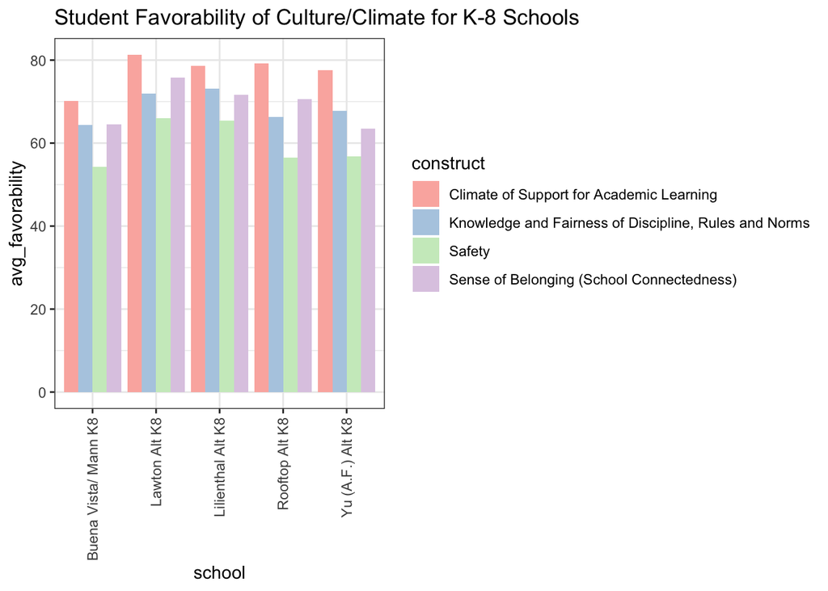

```r
ggplot(filter(surveyDF, domain == 'Culture/Climate') %>%
  group_by(school, construct) %>%
  summarise(avg_favorability = mean(favorability)),
  aes(x = school, y = avg_favorability, fill = construct)) +
  geom_bar(position = 'dodge', stat = 'identity') +
  theme_bw() +
  theme(axis.text.x = element_text(angle = 90, vjust = 0.5, hjust = 1)) +
  labs(title = 'Student Favorability of Culture/Climate for K-8 Schools') +
  scale_fill_brewer(palette = 'Pastel1')
```

Immediately, I see that Lawton student’s have high favor of their school’s climate of support for academic learning – this may be why their students’ assessment scores are higher than other schools. For these K-8 schools, students’ favorability of their school’s safety ranks the lowest among all the other school culture/climate constructs. Hopefully, schools will do something to improve their students’ favorability of their school’s safety. Lawton students have the highest overall favorability over all of the constructs of their school’s culture/climate compared to student’s favorabilities at other schools. Buena Vista students have the lowest overall favorability over all of the constructs of their school’s culture/climate compared to student’s favorabilities at other schools.

Now let’s see each school’s ELASS & MathSS. We’ve seen these before, when we looked at student performance for all eight K-8 schools, but we’ll recreate it with only the five k-8 schools who completed surveys.

```r
testScoreDF %>%
  pivot_longer(cols = c('ELASS', 'MathSS'), names_to = 'Measurement',
               values_to = 'Score') %>%
  group_by(School, Measurement) %>%
  summarise(Avg_Score = mean(Score))
```

```
## # A tibble: 10 × 3
## # Groups:   School [5]
##    School               Measurement Avg_Score
##    <chr>                <chr>           <dbl>
##  1 Buena Vista/ Mann K8 ELASS           2445.
##  2 Buena Vista/ Mann K8 MathSS          2460.
##  3 Lawton Alt K8        ELASS           2585.
##  4 Lawton Alt K8        MathSS          2601.
##  5 Lilienthal Alt K8    ELASS           2582.
##  6 Lilienthal Alt K8    MathSS          2586.
##  7 Rooftop Alt K8       ELASS           2536.
##  8 Rooftop Alt K8       MathSS          2541.
##  9 Yu (A.F.) Alt K8     ELASS           2581.
## 10 Yu (A.F.) Alt K8     MathSS          2592.
```

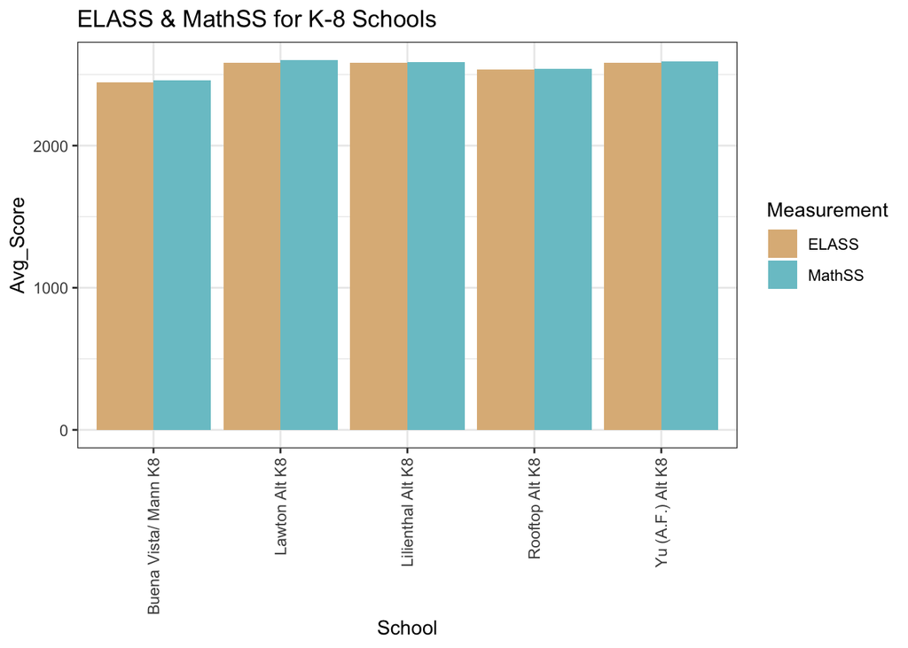

```r
ggplot(testScoreDF %>%
  pivot_longer(cols = c('ELASS', 'MathSS'), names_to = 'Measurement',
               values_to = 'Score') %>%
  group_by(School, Measurement) %>%
  summarise(Avg_Score = mean(Score)),
  aes(x = School, y = Avg_Score, fill = Measurement)) +
  geom_bar(position = 'dodge', stat = 'identity') +
  theme_bw() +
  theme(axis.text.x = element_text(angle = 90, vjust = 0.5, hjust = 1)) +
  labs(title = 'ELASS & MathSS for K-8 Schools') +
  scale_fill_manual(values = c('burlywood', 'cadetblue3'))
```

# Culture Climate - Program Groups

```r
filter(surveyDF, domain == 'Culture/Climate' & group %in% c('SPED', 'Low SES', 'ELL')) %>%
  group_by(school, group, construct) %>%
  summarise(avg_favorability = mean(favorability))
```

```
## # A tibble: 36 × 4
## # Groups:   school, group [9]
##    school               group   construct                       avg_favorability
##    <chr>                <chr>   <chr>                                      <dbl>
##  1 Buena Vista/ Mann K8 ELL     Climate of Support for Academi…             73
##  2 Buena Vista/ Mann K8 ELL     Knowledge and Fairness of Disc…             67
##  3 Buena Vista/ Mann K8 ELL     Safety                                      52.5
##  4 Buena Vista/ Mann K8 ELL     Sense of Belonging (School Con…             65
##  5 Buena Vista/ Mann K8 Low SES Climate of Support for Academi…             71.5
##  6 Buena Vista/ Mann K8 Low SES Knowledge and Fairness of Disc…             65
##  7 Buena Vista/ Mann K8 Low SES Safety                                      55.5
##  8 Buena Vista/ Mann K8 Low SES Sense of Belonging (School Con…             67
##  9 Buena Vista/ Mann K8 SPED    Climate of Support for Academi…             65.5
## 10 Buena Vista/ Mann K8 SPED    Knowledge and Fairness of Disc…             61.5
## # ℹ 26 more rows
```

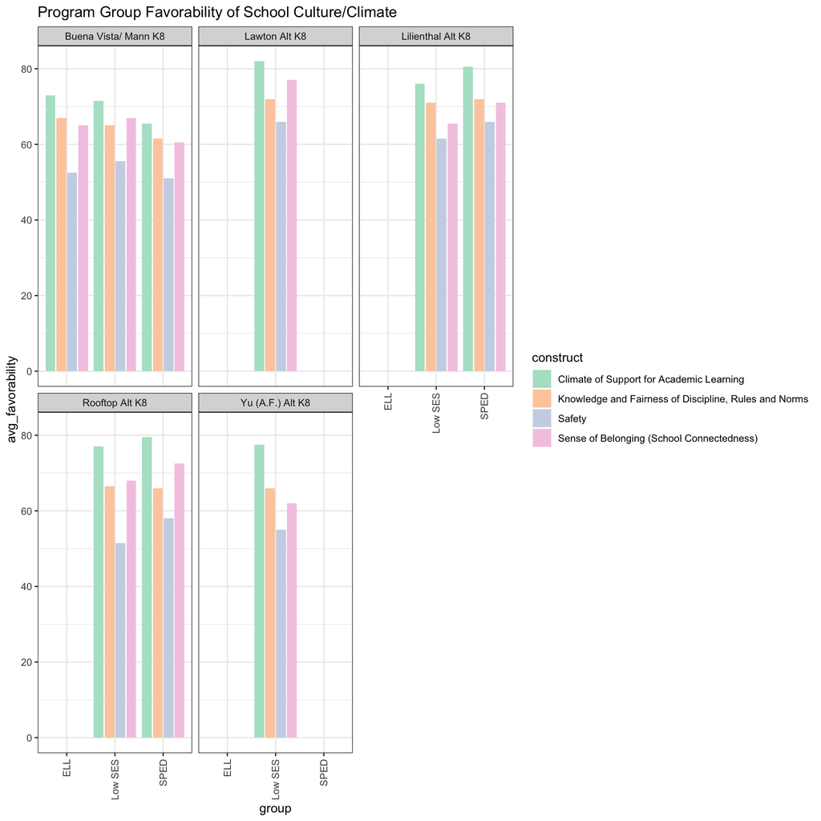

```r
ggplot(filter(surveyDF, domain == 'Culture/Climate' & group %in% c('SPED', 'Low SES', 'ELL')) %>%
  group_by(school, group, construct) %>%
  summarise(avg_favorability = mean(favorability)),
  aes(x = group, y = avg_favorability, fill = construct)) +
  geom_bar(position = position_dodge2(width = 0.5, preserve = 'single'), stat = 'identity') +
  facet_wrap(~ school) +
  theme_bw() +
  theme(axis.text.x = element_text(angle = 90, vjust = 0.5, hjust = 1)) +
  labs(title = 'Program Group Favorability of School Culture/Climate') +
  scale_fill_brewer(palette = 'Pastel2')
```

Across all program groups for each K-8 school, the favorability of the school’s culture/climate follows a similar pattern. Student favorability of their school peaks for climate of support for academic learning, dips for knowledge & fairness of discipline rules & norms, dips again for safety, then peaks for sense of belonging. I wonder if all of these schools being part of the same district has any effect on this similar student favorability for their school’s culture/climate constructs. It’s also surprising that ELL students did not complete the survey for Lawton, Lilienthal, Rooftop, & Yu A.F. SPED students did not complete the survey for Lawton & Yu A.F. We will take these into account when we look at program group students’ performance.

Now let’s look at student performance for these five K-8 schools, grouped by school & program group. Since our ‘ProgramGroup’ variable contains non-independent values, we will perform our transformations separately. EL performance, Low SES performance, & SPED performance:

```r
englishLearner <- filter(testScoreDF, grepl('EL', ProgramGroup) & School == 'Buena Vista/ Mann K8') %>%
  pivot_longer(cols = c('ELASS', 'MathSS'), names_to = 'Measurement',
               values_to = 'Score') %>%
  group_by(School, Measurement) %>%
  summarise(Avg_Score = mean(Score)) %>%
  mutate(ProgramGroup = 'EL') %>% as_tibble()
socioEconomicStatus <- filter(testScoreDF, grepl('SES', ProgramGroup)) %>%
  pivot_longer(cols = c('ELASS', 'MathSS'), names_to = 'Measurement',
               values_to = 'Score') %>%
  group_by(School, Measurement) %>%
  summarise(Avg_Score = mean(Score)) %>%
  mutate(ProgramGroup = 'SES') %>% as_tibble()
specialEd <- filter(testScoreDF, grepl('SPED', ProgramGroup), School %in% c('Buena Vista/ Mann K8', 'Lilienthal Alt K8', 'Rooftop Alt K8')) %>%
  pivot_longer(cols = c('ELASS', 'MathSS'), names_to = 'Measurement',
               values_to = 'Score') %>%
  group_by(School, Measurement) %>%
  summarise(Avg_Score = mean(Score)) %>%
  mutate(ProgramGroup = 'SPED') %>% as_tibble()
programGroupDF <- rbind(englishLearner, socioEconomicStatus, specialEd)
programGroupDF
```

```
## # A tibble: 18 × 4
##    School               Measurement Avg_Score ProgramGroup
##    <chr>                <chr>           <dbl> <chr>
##  1 Buena Vista/ Mann K8 ELASS           2382. EL
##  2 Buena Vista/ Mann K8 MathSS          2403. EL
##  3 Buena Vista/ Mann K8 ELASS           2416. SES
##  4 Buena Vista/ Mann K8 MathSS          2435. SES
##  5 Lawton Alt K8        ELASS           2576. SES
##  6 Lawton Alt K8        MathSS          2590. SES
##  7 Lilienthal Alt K8    ELASS           2556. SES
##  8 Lilienthal Alt K8    MathSS          2557. SES
##  9 Rooftop Alt K8       ELASS           2480. SES
## 10 Rooftop Alt K8       MathSS          2486. SES
## 11 Yu (A.F.) Alt K8     ELASS           2582. SES
## 12 Yu (A.F.) Alt K8     MathSS          2598. SES
## 13 Buena Vista/ Mann K8 ELASS           2470. SPED
## 14 Buena Vista/ Mann K8 MathSS          2480. SPED
## 15 Lilienthal Alt K8    ELASS           2588. SPED
## 16 Lilienthal Alt K8    MathSS          2592. SPED
## 17 Rooftop Alt K8       ELASS           2552. SPED
## 18 Rooftop Alt K8       MathSS          2554. SPED
```

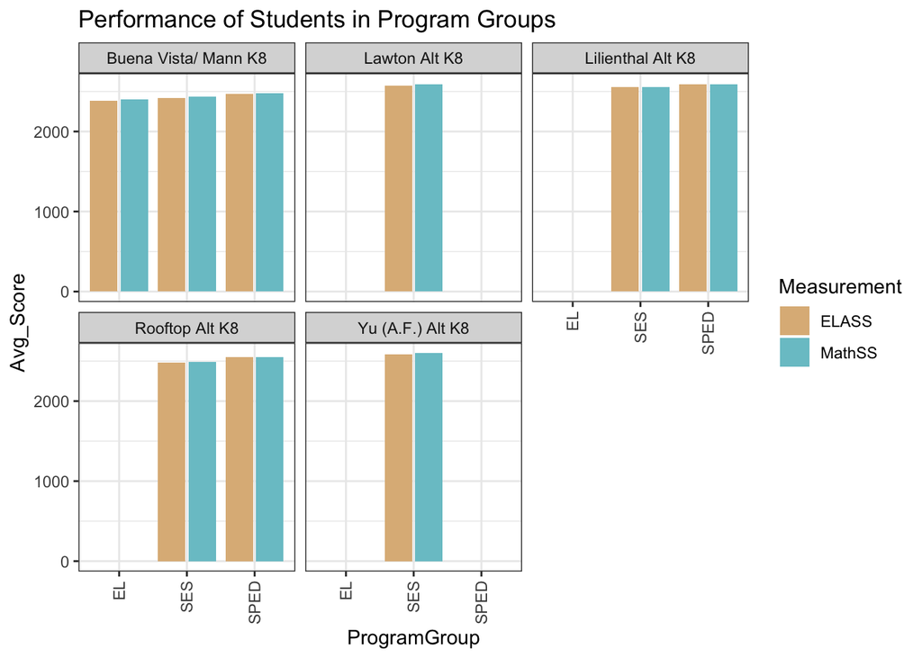

```r
ggplot(programGroupDF,
       aes(x = ProgramGroup, y = Avg_Score, fill = Measurement)) +
  geom_bar(position = position_dodge2(width = 0.5, preserve = 'single'), stat = 'identity') +
  facet_wrap(~ School) +
  theme_bw() +
  theme(axis.text.x = element_text(angle = 90, vjust = 0.5, hjust = 1)) +
  labs(title = 'Performance of Students in Program Groups') +
  scale_fill_manual(values = c('burlywood', 'cadetblue3'))
```

# Culture/Climate - Ethnic Groups

```r
filter(surveyDF, domain == 'Culture/Climate' & group %in% c('African American', 'Hispanic/Latino', 'Asian', 'White')) %>%
  group_by(school, group, construct) %>%
  summarise(avg_favorability = mean(favorability))
```

```
## # A tibble: 36 × 4
## # Groups:   school, group [9]
##    school               group           construct               avg_favorability
##    <chr>                <chr>           <chr>                              <dbl>
##  1 Buena Vista/ Mann K8 Hispanic/Latino Climate of Support for…             70.5
##  2 Buena Vista/ Mann K8 Hispanic/Latino Knowledge and Fairness…             64
##  3 Buena Vista/ Mann K8 Hispanic/Latino Safety                              58
##  4 Buena Vista/ Mann K8 Hispanic/Latino Sense of Belonging (Sc…             65.5
##  5 Lawton Alt K8        Asian           Climate of Support for…             80.5
##  6 Lawton Alt K8        Asian           Knowledge and Fairness…             72
##  7 Lawton Alt K8        Asian           Safety                              66
##  8 Lawton Alt K8        Asian           Sense of Belonging (Sc…             74.5
##  9 Lilienthal Alt K8    Asian           Climate of Support for…             78
## 10 Lilienthal Alt K8    Asian           Knowledge and Fairness…             75.5
## # ℹ 26 more rows
```

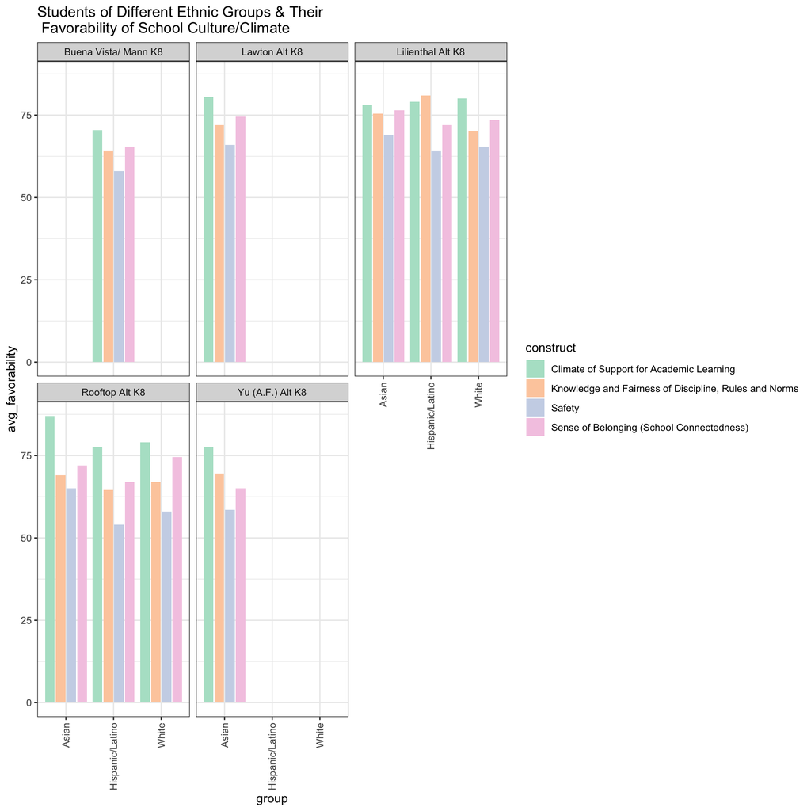

```r
ggplot(filter(surveyDF, domain == 'Culture/Climate' & group %in% c('African American', 'Hispanic/Latino', 'Asian', 'White')) %>%
  group_by(school, group, construct) %>%
  summarise(avg_favorability = mean(favorability)),
  aes(x = group, y = avg_favorability, fill = construct)) +
  geom_bar(position = position_dodge2(width = 0.5, preserve = 'single'), stat = 'identity') +
  facet_wrap(~ school) +
  theme_bw() +
  theme(axis.text.x = element_text(angle = 90, vjust = 0.5, hjust = 1)) +
  labs(title = 'Students of Different Ethnic Groups & Their \n Favorability of School Culture/Climate') +
  scale_fill_brewer(palette = 'Pastel2')
```

Surprisingly, Buena Vista only had Hispanic/Latino students who completed the survey. Lawton & Yu A.F. only had Asian students who completed the survey. It’s difficult to see if there is any pattern in favorability of school culture/climate from students of different ethnic backgrounds, when not all students from different ethnic groups completed the survey. Asian, Hispanic/Latino, & White students’ favorability of Lilienthal’s culture/climate seems fairly similar. Based of the survey responses from Rooftop, Asian students have higher favorability of their school’s culture & climate compared to Hispanic/Latino or White students. Hispanic/Latino & White students at Rooftop seem to have similar favorability of their school’s culture/climate.

Now let’s look into performance from students of different ethnic backgrounds, taking into account that some some schools do not have survey responses from certain ethnic groups.

```r
filter(testScoreDF, School %in% c('Lilienthal Alt K8', 'Rooftop Alt K8') | (School %in% c('Lawton Alt K8', 'Yu (A.F.) Alt K8') & EthnicGroup == 'Asian') | (School == 'Buena Vista/ Mann K8' & EthnicGroup == 'HL')) %>%
  pivot_longer(cols = c('ELASS', 'MathSS'), names_to = 'Measurement',
               values_to = 'Score') %>%
  group_by(School, EthnicGroup, Measurement) %>%
  summarise(Avg_Score = mean(Score))
```

```
## # A tibble: 18 × 4
## # Groups:   School, EthnicGroup [9]
##    School               EthnicGroup Measurement Avg_Score
##    <chr>                <chr>       <chr>           <dbl>
##  1 Buena Vista/ Mann K8 HL          ELASS           2431.
##  2 Buena Vista/ Mann K8 HL          MathSS          2448.
##  3 Lawton Alt K8        Asian       ELASS           2584.
##  4 Lawton Alt K8        Asian       MathSS          2601.
##  5 Lilienthal Alt K8    Asian       ELASS           2597.
##  6 Lilienthal Alt K8    Asian       MathSS          2609.
##  7 Lilienthal Alt K8    HL          ELASS           2537.
##  8 Lilienthal Alt K8    HL          MathSS          2525.
##  9 Lilienthal Alt K8    White       ELASS           2583.
## 10 Lilienthal Alt K8    White       MathSS          2584.
## 11 Rooftop Alt K8       Asian       ELASS           2557.
## 12 Rooftop Alt K8       Asian       MathSS          2571.
## 13 Rooftop Alt K8       HL          ELASS           2477.
## 14 Rooftop Alt K8       HL          MathSS          2467.
## 15 Rooftop Alt K8       White       ELASS           2564.
## 16 Rooftop Alt K8       White       MathSS          2574.
## 17 Yu (A.F.) Alt K8     Asian       ELASS           2579.
## 18 Yu (A.F.) Alt K8     Asian       MathSS          2593.
```

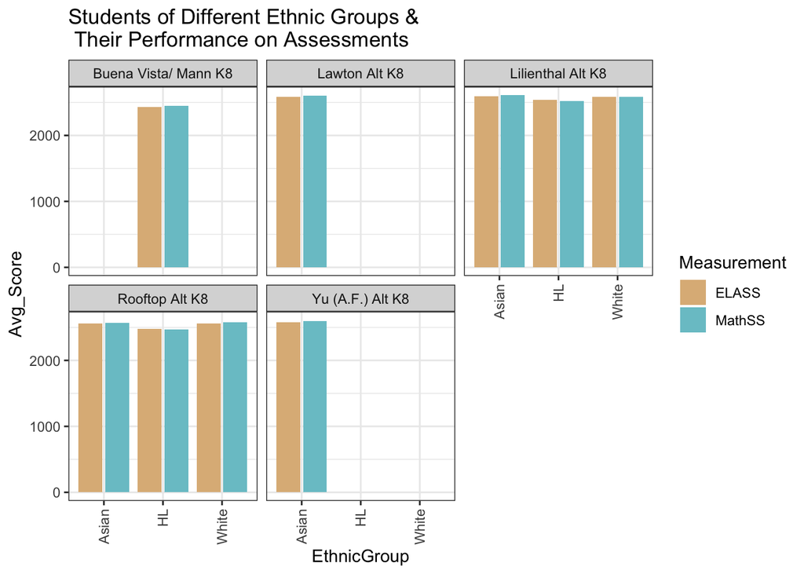

```r
ggplot(filter(testScoreDF, School %in% c('Lilienthal Alt K8', 'Rooftop Alt K8') | (School %in% c('Lawton Alt K8', 'Yu (A.F.) Alt K8') & EthnicGroup == 'Asian') | (School == 'Buena Vista/ Mann K8' & EthnicGroup == 'HL')) %>%
  pivot_longer(cols = c('ELASS', 'MathSS'), names_to = 'Measurement',
               values_to = 'Score') %>%
  group_by(School, EthnicGroup, Measurement) %>%
  summarise(Avg_Score = mean(Score)),
  aes(x = EthnicGroup, y = Avg_Score, fill = Measurement)) +
  geom_bar(position = position_dodge2(width = 0.5, preserve = 'single'), stat = 'identity') +
  facet_wrap(~ School) +
  theme_bw() +
  theme(axis.text.x = element_text(angle = 90, vjust = 0.5, hjust = 1)) +
  labs(title = 'Students of Different Ethnic Groups & \n Their Performance on Assessments') +
  scale_fill_manual(values = c('burlywood', 'cadetblue3'))
```

Asian & White students seem to perform very well on their assessments, regardless of what K-8 school they attend. Hispanic/Latino students perform worse than Asian & White students on their assessments. I can see somewhat of a relationship between favorabilities of students from different ethnic groups for their school & their performance on their assessments. Hispanic/Latino students from Buena Vista have the lowest overall favorability for their school’s culture/climate, & perform the worst on their assessments, compared to students of the same or different ethnic backgrounds from other schools. Lawton students & Lilienthal students have similarly high favorability of their school’s culture/climate & they perform similarly, quite well actually, on their English & Math assessments. Rooftop’s Asian students have high favorability of their school’s climate of support for academic learning, but overall, Rooftop’s culture/climate favorability across all ethnic groups who completed the survey is lower than that of Lilienthal’s. This is reflected in Rooftop & Lilienthal’s student performance scores – Lilienthal’s students performing slightly better than Rooftop’s students, across all ethnic groups who completed the survey.

# Growth Mindset

Now, let’s look at students’ growth mindset. We can get a decent idea of what a student’s growth mindset is if we look at their favorability of the growth mindset constructs.

```r
filter(surveyDF, domain == 'Social-Emotional Learning') %>%
  group_by(school, construct) %>%
  summarise(avg_favorability = mean(favorability))
```

```
## # A tibble: 20 × 3
## # Groups:   school [5]
##    school               construct        avg_favorability
##    <chr>                <chr>                       <dbl>
##  1 Buena Vista/ Mann K8 Growth Mindset               46.9
##  2 Buena Vista/ Mann K8 Self-Efficacy                41.5
##  3 Buena Vista/ Mann K8 Self-Management              60.9
##  4 Buena Vista/ Mann K8 Social Awareness             54.2
##  5 Lawton Alt K8        Growth Mindset               63.8
##  6 Lawton Alt K8        Self-Efficacy                53.5
##  7 Lawton Alt K8        Self-Management              80.5
##  8 Lawton Alt K8        Social Awareness             62.2
##  9 Lilienthal Alt K8    Growth Mindset               69
## 10 Lilienthal Alt K8    Self-Efficacy                58.7
## 11 Lilienthal Alt K8    Self-Management              77.9
## 12 Lilienthal Alt K8    Social Awareness             65.2
## 13 Rooftop Alt K8       Growth Mindset               65.7
## 14 Rooftop Alt K8       Self-Efficacy                59.2
## 15 Rooftop Alt K8       Self-Management              76.3
## 16 Rooftop Alt K8       Social Awareness             65.3
## 17 Yu (A.F.) Alt K8     Growth Mindset               60.2
## 18 Yu (A.F.) Alt K8     Self-Efficacy                54.5
## 19 Yu (A.F.) Alt K8     Self-Management              75.5
## 20 Yu (A.F.) Alt K8     Social Awareness             62
```

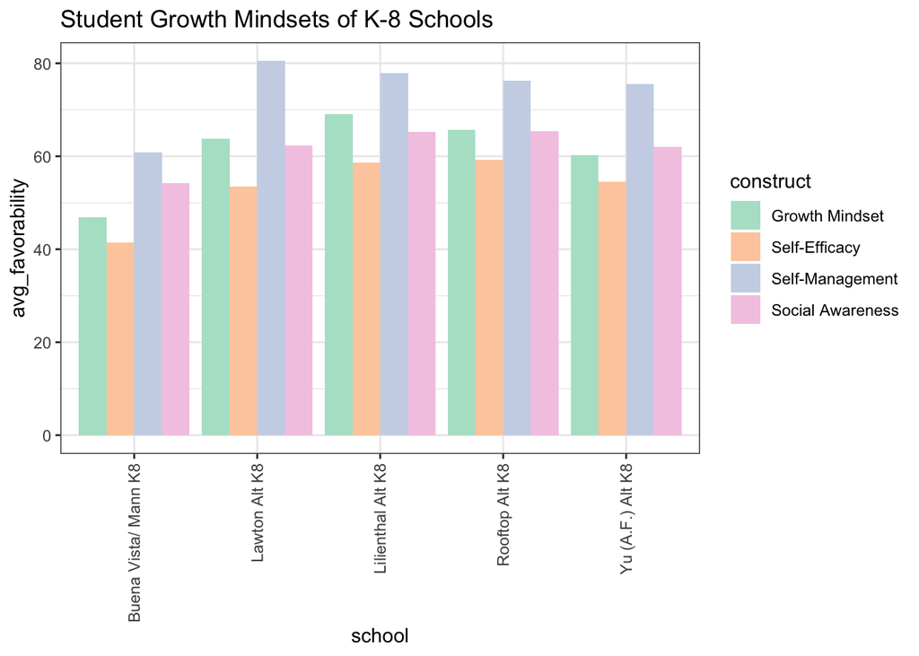

```r
ggplot(filter(surveyDF, domain == 'Social-Emotional Learning') %>%
  group_by(school, construct) %>%
  summarise(avg_favorability = mean(favorability)),
  aes(x = school, y = avg_favorability, fill = construct)) +
  geom_bar(position = 'dodge', stat = 'identity') +
  theme_bw() +
  theme(axis.text.x = element_text(angle = 90, vjust = 0.5, hjust = 1)) +
  labs(title = 'Student Growth Mindsets of K-8 Schools ') +
  scale_fill_brewer(palette = 'Pastel2')
```

Firstly, I find it’s interesting how the structure of the favorability patterns seem similar for each school. We start off with a little peak for growth mindset, a dip for self-efficacy, a strong peak for self-management, then a peak once again for social awareness. Buena Vista has the lowest favorability out of the five K-8 schools for every construct in the growth mindset domain. It seems that Lilienthal students have the highest overall favorability of their own growth mindsets, followed Lawton & Rooftop students, then Yu A.F. students. Self-management has the highest average favorability for students in these five K-8 schools & self-efficacy has the lowest.

Now let’s look at student performance the English & Math assessments for each school again, & see if there can be a relationship between students’ growth mindset & their assessment scores.

```r
testScoreDF %>%
  pivot_longer(cols = c('ELASS', 'MathSS'), names_to = 'Measurement',
               values_to = 'Score') %>%
  group_by(School, Measurement) %>%
  summarise(Avg_Score = mean(Score))
```

```
## # A tibble: 10 × 3
## # Groups:   School [5]
##    School               Measurement Avg_Score
##    <chr>                <chr>           <dbl>
##  1 Buena Vista/ Mann K8 ELASS           2445.
##  2 Buena Vista/ Mann K8 MathSS          2460.
##  3 Lawton Alt K8        ELASS           2585.
##  4 Lawton Alt K8        MathSS          2601.
##  5 Lilienthal Alt K8    ELASS           2582.
##  6 Lilienthal Alt K8    MathSS          2586.
##  7 Rooftop Alt K8       ELASS           2536.
##  8 Rooftop Alt K8       MathSS          2541.
##  9 Yu (A.F.) Alt K8     ELASS           2581.
## 10 Yu (A.F.) Alt K8     MathSS          2592.
```

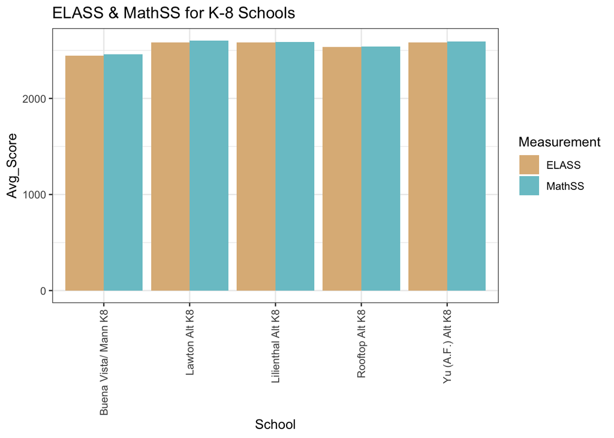

```r
ggplot(testScoreDF %>%
  pivot_longer(cols = c('ELASS', 'MathSS'), names_to = 'Measurement',
               values_to = 'Score') %>%
  group_by(School, Measurement) %>%
  summarise(Avg_Score = mean(Score)),
  aes(x = School, y = Avg_Score, fill = Measurement)) +
  geom_bar(position = 'dodge', stat = 'identity') +
  theme_bw() +
  theme(axis.text.x = element_text(angle = 90, vjust = 0.5, hjust = 1)) +
  labs(title = 'ELASS & MathSS for K-8 Schools') +
  scale_fill_manual(values = c('burlywood', 'cadetblue3'))
```

From the looks of it, there could be a possible positive relationship between students’ favorability of their own growth mindsets & their performance on the English & Math assessments, though having no id to connect the survey responses & perfomance on assessments building a model to explain this relationship not possible. We can only make observations of the figures. Buena Vista’s students have the lowest overall favorability of their own growth mindsets, & perform the worst of the five K-8 schools on their English & Math assessments. Lilienthal, Lawton, & Yu A.F.’s students see a slight decrease in overall favorability of their own growth mindsets, in that order, but seem to perform similarly well in their performance assessments. Lilienthal’s students have the greatest favorability of their own growth mindset & Lawton’s students perform the best on their assessments.

# Growth Mindset - Program Groups

Let’s look at students’ growth mindsets separated by their program groups.

```r
filter(surveyDF, domain == 'Social-Emotional Learning' & group %in% c('ELL', 'Low SES', 'SPED')) %>%
  group_by(school, group, construct) %>%
  summarise(avg_favorability = mean(favorability))
```

```
## # A tibble: 36 × 4
## # Groups:   school, group [9]
##    school               group   construct        avg_favorability
##    <chr>                <chr>   <chr>                       <dbl>
##  1 Buena Vista/ Mann K8 ELL     Growth Mindset               42.5
##  2 Buena Vista/ Mann K8 ELL     Self-Efficacy                40.5
##  3 Buena Vista/ Mann K8 ELL     Self-Management              59.5
##  4 Buena Vista/ Mann K8 ELL     Social Awareness             53.5
##  5 Buena Vista/ Mann K8 Low SES Growth Mindset               47.5
##  6 Buena Vista/ Mann K8 Low SES Self-Efficacy                46
##  7 Buena Vista/ Mann K8 Low SES Self-Management              65
##  8 Buena Vista/ Mann K8 Low SES Social Awareness             58.5
##  9 Buena Vista/ Mann K8 SPED    Growth Mindset               47
## 10 Buena Vista/ Mann K8 SPED    Self-Efficacy                34
## # ℹ 26 more rows
```

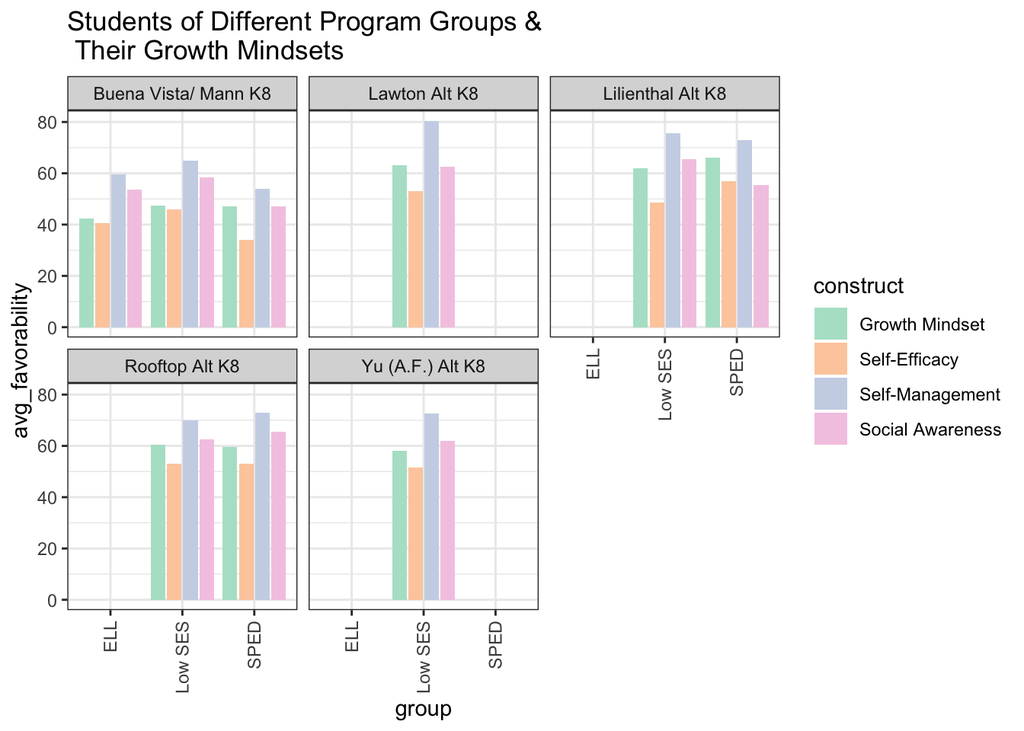

```r
ggplot(filter(surveyDF, domain == 'Social-Emotional Learning' & group %in% c('ELL', 'Low SES', 'SPED')) %>%
  group_by(school, group, construct) %>%
  summarise(avg_favorability = mean(favorability)),
  aes(x = group, y = avg_favorability, fill = construct)) +
  geom_bar(position = position_dodge2(width = 0.5, preserve = 'single'), stat = 'identity') +
  facet_wrap(~ school) +
  theme_bw() +
  theme(axis.text.x = element_text(angle = 90, vjust = 0.5, hjust = 1)) +
  labs(title = 'Students of Different Program Groups & \n Their Growth Mindsets') +
  scale_fill_brewer(palette = 'Pastel2')
```

Immediately we can see that Buena Vista’s students, regardless of the program group that they belong in, score very low on their favorability of their growth mindsets. Lawton only had low SES students who completed the survey, & they had high favorability of their growth mindset, despite being low SES. Lilienthal’s low SES & SPED program groups had similar overall favorability of their growth mindsets across its constructs, but lower favorability than Lawton’s low SES students. Rooftop had low SES & SPED students as well & they scored similar overall favorabilities across all constructs of their growth mindsets to Lilienthal’s students of the same program group. Yu A.F’s Low SES students is comparable to Lawton’s low SES students, but much less favorability of their own growth mindsets, despite performing similarly on their assessments, as we know from earlier.

Let’s look once again at student performance on their English & Math assessments for each school, taking into account that not all schools have students of certain program groups who completed the survey.

```r
programGroupDF
```

```
## # A tibble: 18 × 4
##    School               Measurement Avg_Score ProgramGroup
##    <chr>                <chr>           <dbl> <chr>
##  1 Buena Vista/ Mann K8 ELASS           2382. EL
##  2 Buena Vista/ Mann K8 MathSS          2403. EL
##  3 Buena Vista/ Mann K8 ELASS           2416. SES
##  4 Buena Vista/ Mann K8 MathSS          2435. SES
##  5 Lawton Alt K8        ELASS           2576. SES
##  6 Lawton Alt K8        MathSS          2590. SES
##  7 Lilienthal Alt K8    ELASS           2556. SES
##  8 Lilienthal Alt K8    MathSS          2557. SES
##  9 Rooftop Alt K8       ELASS           2480. SES
## 10 Rooftop Alt K8       MathSS          2486. SES
## 11 Yu (A.F.) Alt K8     ELASS           2582. SES
## 12 Yu (A.F.) Alt K8     MathSS          2598. SES
## 13 Buena Vista/ Mann K8 ELASS           2470. SPED
## 14 Buena Vista/ Mann K8 MathSS          2480. SPED
## 15 Lilienthal Alt K8    ELASS           2588. SPED
## 16 Lilienthal Alt K8    MathSS          2592. SPED
## 17 Rooftop Alt K8       ELASS           2552. SPED
## 18 Rooftop Alt K8       MathSS          2554. SPED
```

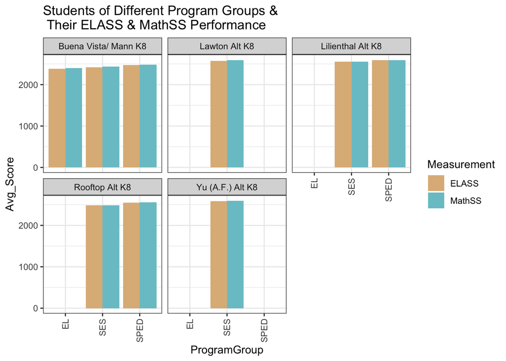

```r
ggplot(programGroupDF,
       aes(x = ProgramGroup, y = Avg_Score, fill = Measurement)) +
  geom_bar(position = 'dodge', stat = 'identity') +
  facet_wrap(~ School) +
  theme_bw() +
  theme(axis.text.x = element_text(angle = 90, vjust = 0.5, hjust = 1)) +
  labs(title = 'Students of Different Program Groups & \n Their ELASS & MathSS Performance') +
  scale_fill_manual(values = c('burlywood', 'cadetblue3'))
```

Based off this figure & the corresponding figure on favorability of students in program groups per school, there could a possible positive relationship between favorability of students’ growth mindsets & their performance on their English/Math assessments, but performance variance between program groups is hard to distinguish because there is no id for a student allowing us to form a connection between favorability & assessment scores. In Buena Vista, Low SES students have the highest overall favorability of their own growth mindsets, next is ELL & last is SPED. But when we look at their average performance, we see the low SES students have greater assessment scores than EL students, & SPED students greater scores than low SES students. Lilienthal & Rooftop’s low SES & SPED students seem to have similar overall favorabilities of their growth mindsets. When we look at their average assessment scores, SPED students perform better than SES students on their assessments in both schools – Lilienthal’s students performing slightly better overall than Rooftop for both program groups. Restated from before, Lawton’s low SES group sees the highest overall favorability of all program groups in these five K-8 schools. Yu A.F.’s low SES students sees lower favorability than Lawton’s low SES students, but perform slightly better than Lawton’s students on their assessments. I wonder why Yu A.F.’s students perform so well but have lower favorability of their own growth mindsets than Lawton’s students. Both Lawton & Yu A.F.’s students are predominantly Asian, so it may not be an ethnic group count difference. Could it be something related to curriculum or the way the student’s are treated that make them feel unfavorable of their own growth mindset?

# Growth Mindset - Ethnic Groups

Here’s the average favorability of each construct from each ethnic group for each school.

```r
filter(surveyDF, domain == 'Social-Emotional Learning' & group %in% c('African American', 'Hispanic/Latino', 'Asian', 'White')) %>%
  group_by(school, group, construct) %>%
  summarise(avg_favorability = mean(favorability))
```

```
## # A tibble: 36 × 4
## # Groups:   school, group [9]
##    school               group           construct        avg_favorability
##    <chr>                <chr>           <chr>                       <dbl>
##  1 Buena Vista/ Mann K8 Hispanic/Latino Growth Mindset               50.5
##  2 Buena Vista/ Mann K8 Hispanic/Latino Self-Efficacy                45.5
##  3 Buena Vista/ Mann K8 Hispanic/Latino Self-Management              65
##  4 Buena Vista/ Mann K8 Hispanic/Latino Social Awareness             58
##  5 Lawton Alt K8        Asian           Growth Mindset               64.5
##  6 Lawton Alt K8        Asian           Self-Efficacy                54
##  7 Lawton Alt K8        Asian           Self-Management              80.5
##  8 Lawton Alt K8        Asian           Social Awareness             62
##  9 Lilienthal Alt K8    Asian           Growth Mindset               73
## 10 Lilienthal Alt K8    Asian           Self-Efficacy                62.5
## # ℹ 26 more rows
```

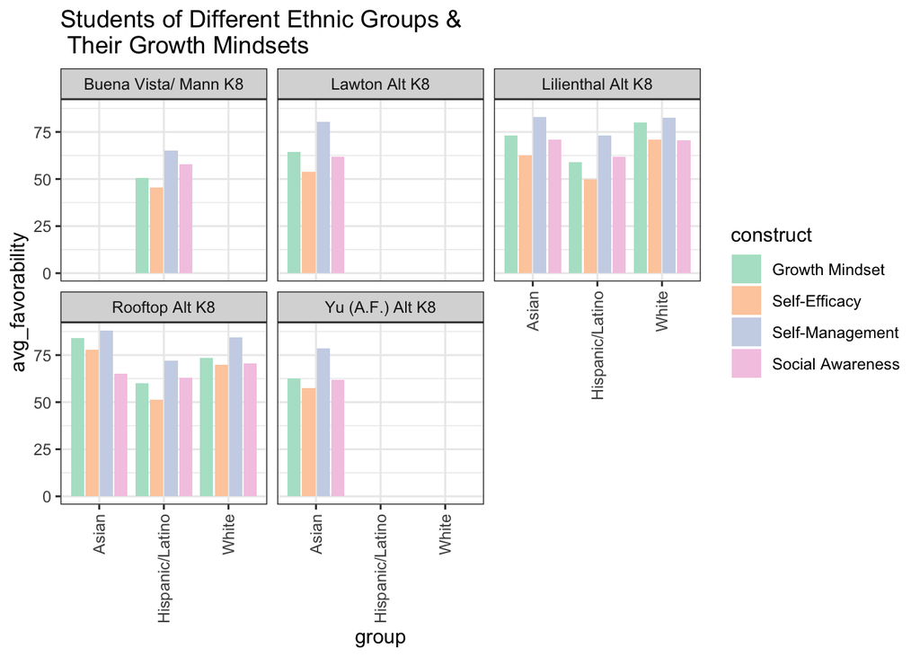

```r
ggplot(filter(surveyDF, domain == 'Social-Emotional Learning' & group %in% c('African American', 'Hispanic/Latino', 'Asian', 'White')) %>%
  group_by(school, group, construct) %>%
  summarise(avg_favorability = mean(favorability)),
  aes(x = group, y = avg_favorability, fill = construct)) +
  geom_bar(position = position_dodge2(width = 0.5, preserve = 'single'), stat = 'identity') +
  facet_wrap(~ school) +
  theme_bw() +
  theme(axis.text.x = element_text(angle = 90, vjust = 0.5, hjust = 1)) +
  labs(title = 'Students of Different Ethnic Groups & \n Their Growth Mindsets') +
  scale_fill_brewer(palette = 'Pastel2')
```

Now here’s the average assessment scores of each ethnic group for each school, accounting for the ethic groups who did not complete the survey for each school.

```r
filter(testScoreDF, School %in% c('Lilienthal Alt K8', 'Rooftop Alt K8') | (School %in% c('Lawton Alt K8', 'Yu (A.F.) Alt K8') & EthnicGroup == 'Asian') | (School == 'Buena Vista/ Mann K8' & EthnicGroup == 'HL')) %>%
  pivot_longer(cols = c('ELASS', 'MathSS'), names_to = 'Measurement',
               values_to = 'Score') %>%
  group_by(School, EthnicGroup, Measurement) %>%
  summarise(Avg_Score = mean(Score))
```

```
## # A tibble: 18 × 4
## # Groups:   School, EthnicGroup [9]
##    School               EthnicGroup Measurement Avg_Score
##    <chr>                <chr>       <chr>           <dbl>
##  1 Buena Vista/ Mann K8 HL          ELASS           2431.
##  2 Buena Vista/ Mann K8 HL          MathSS          2448.
##  3 Lawton Alt K8        Asian       ELASS           2584.
##  4 Lawton Alt K8        Asian       MathSS          2601.
##  5 Lilienthal Alt K8    Asian       ELASS           2597.
##  6 Lilienthal Alt K8    Asian       MathSS          2609.
##  7 Lilienthal Alt K8    HL          ELASS           2537.
##  8 Lilienthal Alt K8    HL          MathSS          2525.
##  9 Lilienthal Alt K8    White       ELASS           2583.
## 10 Lilienthal Alt K8    White       MathSS          2584.
## 11 Rooftop Alt K8       Asian       ELASS           2557.
## 12 Rooftop Alt K8       Asian       MathSS          2571.
## 13 Rooftop Alt K8       HL          ELASS           2477.
## 14 Rooftop Alt K8       HL          MathSS          2467.
## 15 Rooftop Alt K8       White       ELASS           2564.
## 16 Rooftop Alt K8       White       MathSS          2574.
## 17 Yu (A.F.) Alt K8     Asian       ELASS           2579.
## 18 Yu (A.F.) Alt K8     Asian       MathSS          2593.
```

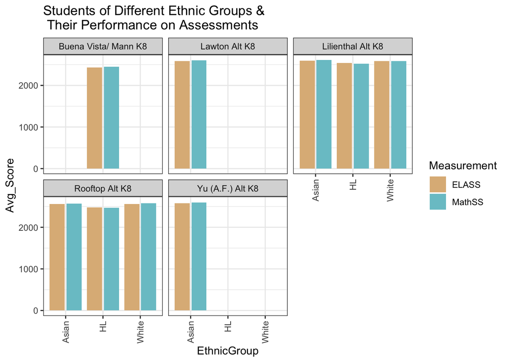

```r
ggplot(filter(testScoreDF, School %in% c('Lilienthal Alt K8', 'Rooftop Alt K8') | (School %in% c('Lawton Alt K8', 'Yu (A.F.) Alt K8') & EthnicGroup == 'Asian') | (School == 'Buena Vista/ Mann K8' & EthnicGroup == 'HL')) %>%
  pivot_longer(cols = c('ELASS', 'MathSS'), names_to = 'Measurement',
               values_to = 'Score') %>%
  group_by(School, EthnicGroup, Measurement) %>%
  summarise(Avg_Score = mean(Score)),
  aes(x = EthnicGroup, y = Avg_Score, fill = Measurement)) +
  geom_bar(position = position_dodge2(width = 0.5, preserve = 'single'), stat = 'identity') +
  facet_wrap(~ School) +
  theme_bw() +
  theme(axis.text.x = element_text(angle = 90, vjust = 0.5, hjust = 1)) +
  labs(title = 'Students of Different Ethnic Groups & \n Their Performance on Assessments') +
  scale_fill_manual(values = c('burlywood', 'cadetblue3'))
```